# Naste Nutrient Analysis

Jessica Glazner

2024-11-09

### Summary of findings:

#### TIN: dosing - G and E same, all others different, aquaria - all treatments the same. While initial treatments had different TIN, the corals drew TIN down to same level within tanks no matter delivery concentration.

#### PO4: dosing - Porites were all different but Montipora had e/g and c/i and e/i similar PO4, aquaria - all treatments the same except G which was higher. Drawdown of PO4 occured, but likely P limitation in 3 treatments, only G had more P than could be drawndown

#### N:P: dosing - C = E but all other comparisons are different. I has higher N:P and G has lower N:P, aquaria - G different from all treatments, but all other treatments similar.

```r
#load libraries
library(tidyverse)
library(lme4)
library(emmeans)
#load data
nuts <- read.csv("C:\\Users\\jglaz\\Desktop\\NASTE\\DATA\\water_nuts.csv")
doc <- read.csv("C:\\Users\\jglaz\\Desktop\\NASTE\\DATA\\DOC.csv")
```

## Nut Data Wrangling

```r
# add a TIN (total inorganic nitrogen) column by adding N+N and ammonia columns
nuts <- nuts %>%
  mutate(TIN = N.N + Ammonia)

# add a N:P column from TN/TP

nuts <- nuts %>%
  mutate(N_to_P = TN / TP)

# add a TIN:PO4 column from TIN/PO4

nuts <- nuts %>%
  mutate(TIN_to_PO4 = TIN/Phosphate)


nuts$Tank <- as.factor(nuts$Tank)

mc_nuts <- nuts[nuts$Species == "Montipora",]
pc_nuts <- nuts[nuts$Species == "Porites",]
mc_doc <- doc[doc$Species == "Montipora",]
pc_doc <- doc[doc$Species == "Porites",]
```

```r
write.csv(nuts, file="C:\\Users\\jglaz\\Desktop\\NASTE\\DATA\\naste_nuts.csv")
```

## DOC Data Wrangling

```r
# remove 2 oultliers
doc <- doc %>%
  mutate(NPOC_uM = if_else(SLAB.ID %in% c(31, 46), NA_real_, NPOC_uM))
```

## Set plot theme and colors

```r
 # All of the following plots will follow this theme
theme_set(
  theme_minimal(base_size = 15) +                             # Set base theme
    theme(
      plot.title = element_text(size = 18, face = "bold"),    # Customize title
      axis.title = element_text(size = 15),                   # Customize axis titles
      axis.text = element_text(size = 15),                    # Customize axis text
      legend.title = element_text(size = 15),                 # Customize legend title
      legend.text = element_text(size = 15)                  # Customize legend text
    )
)


# Define colors for the treatments
naste_colors <- c("Control" = "#08b5d3",
               "Effluent" = "#e12618",
               "Guano" = "#01ad74",
               "Inorganic" = "#d9a33a")
```

# TIN

### Dosing

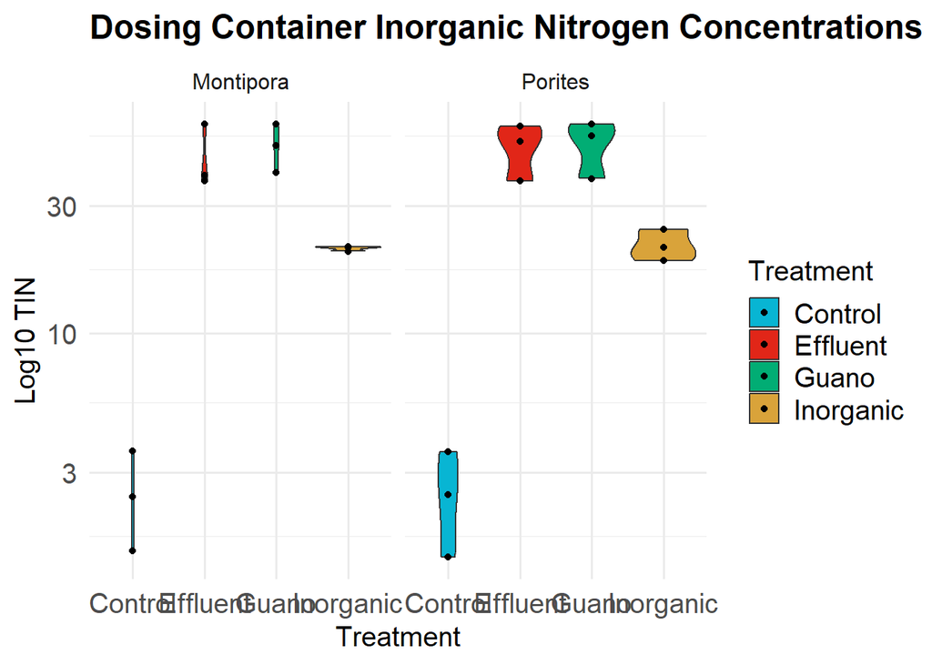

```r
# Violin Plot - TIN pooled at all timepoints
ggplot(data=subset(nuts, Tank %in% c("Dosing")), aes(x=Treatment, y=TIN, fill=Treatment))+
  geom_violin()+
  facet_wrap(~Species) +
  geom_jitter(width=0)+
  ggtitle("Dosing Container Inorganic Nitrogen Concentrations")+
  scale_fill_manual(values=naste_colors)+
  scale_y_continuous(trans = "log10", name = "Log10 TIN")
```

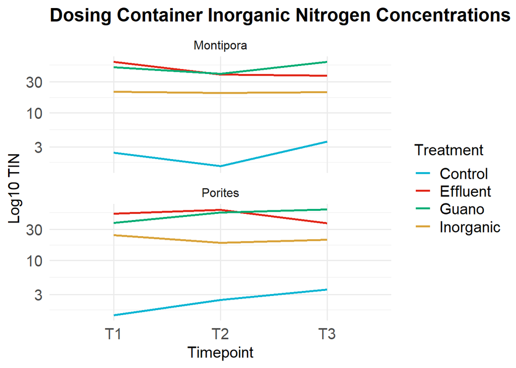

```r
# Line Plot - to show time series of TIN
ggplot(data=subset(nuts, Tank %in% c("Dosing")), aes(x=Timepoint, y=TIN, group=Treatment, color=Treatment))+
  geom_line(size=1)+
  facet_wrap(~Species, ncol = 1)+
  ggtitle("Dosing Container Inorganic Nitrogen Concentrations")+
  scale_color_manual(values= naste_colors)+
  scale_y_continuous(trans = "log10", name = "Log10 TIN")
```

### Analysis of TIN in Dosing - linear model

```r
# pooled Montipora and Porites
TIN_dosing <- nuts %>%
  filter(Tank == "Dosing") %>%
  lm(log10(TIN) ~ Treatment, data = .)
summary(TIN_dosing)
```

```
##
## Call:
## lm(formula = log10(TIN) ~ Treatment, data = .)
##
## Residuals:
##       Min        1Q    Median        3Q       Max
## -0.213380 -0.082665  0.002795  0.071942  0.183352
##
## Coefficients:
##                    Estimate Std. Error t value Pr(>|t|)
## (Intercept)         0.37174    0.04560   8.153 8.69e-08 ***
## TreatmentEffluent   1.29688    0.06449  20.111 9.71e-15 ***
## TreatmentGuano      1.32677    0.06449  20.575 6.28e-15 ***
## TreatmentInorganic  0.95055    0.06449  14.741 3.32e-12 ***
## ---
## Signif. codes:  0 '***' 0.001 '**' 0.01 '*' 0.05 '.' 0.1 ' ' 1
##
## Residual standard error: 0.1117 on 20 degrees of freedom
## Multiple R-squared:  0.9652, Adjusted R-squared:  0.9599
## F-statistic: 184.7 on 3 and 20 DF,  p-value: 9.589e-15
```

```r
emm_tin<- emmeans(TIN_dosing, ~ Treatment)
emm_tin
```

```
##  Treatment emmean     SE df lower.CL upper.CL
##  Control    0.372 0.0456 20    0.277    0.467
##  Effluent   1.669 0.0456 20    1.574    1.764
##  Guano      1.699 0.0456 20    1.603    1.794
##  Inorganic  1.322 0.0456 20    1.227    1.417
##
## Results are given on the log10 (not the response) scale.
## Confidence level used: 0.95
```

```r
pair_tin<- contrast(emm_tin, method='pairwise')
summary(pair_tin)
```

```
##  contrast             estimate     SE df t.ratio p.value
##  Control - Effluent    -1.2969 0.0645 20 -20.111  <.0001
##  Control - Guano       -1.3268 0.0645 20 -20.575  <.0001
##  Control - Inorganic   -0.9505 0.0645 20 -14.741  <.0001
##  Effluent - Guano      -0.0299 0.0645 20  -0.464  0.9661
##  Effluent - Inorganic   0.3463 0.0645 20   5.371  0.0002
##  Guano - Inorganic      0.3762 0.0645 20   5.834  0.0001
##
## Results are given on the log10 (not the response) scale.
## P value adjustment: tukey method for comparing a family of 4 estimates
```

```r
# Guano and Effluent are similar, all other treatments differ from each other

# Montipora
TIN_dosing_m <- mc_nuts %>%
  filter(Tank == "Dosing") %>%
  lm(log10(TIN) ~ Treatment, data = .)
summary(TIN_dosing_m)
```

```
##
## Call:
## lm(formula = log10(TIN) ~ Treatment, data = .)
##
## Residuals:
##       Min        1Q    Median        3Q       Max
## -0.192338 -0.062793  0.005062  0.030546  0.180913
##
## Coefficients:
##                    Estimate Std. Error t value Pr(>|t|)
## (Intercept)         0.37418    0.06907   5.417 0.000633 ***
## TreatmentEffluent   1.27418    0.09768  13.044 1.13e-06 ***
## TreatmentGuano      1.32195    0.09768  13.533 8.53e-07 ***
## TreatmentInorganic  0.94305    0.09768   9.654 1.10e-05 ***
## ---
## Signif. codes:  0 '***' 0.001 '**' 0.01 '*' 0.05 '.' 0.1 ' ' 1
##
## Residual standard error: 0.1196 on 8 degrees of freedom
## Multiple R-squared:  0.9673, Adjusted R-squared:  0.955
## F-statistic: 78.88 on 3 and 8 DF,  p-value: 2.777e-06
```

```r
emm_tin_m<- emmeans(TIN_dosing_m, ~ Treatment)
emm_tin_m
```

```
##  Treatment emmean     SE df lower.CL upper.CL
##  Control    0.374 0.0691  8    0.215    0.533
##  Effluent   1.648 0.0691  8    1.489    1.808
##  Guano      1.696 0.0691  8    1.537    1.855
##  Inorganic  1.317 0.0691  8    1.158    1.477
##
## Results are given on the log10 (not the response) scale.
## Confidence level used: 0.95
```

```r
pair_tin_m<- contrast(emm_tin_m, method='pairwise')
summary(pair_tin_m)
```

```
##  contrast             estimate     SE df t.ratio p.value
##  Control - Effluent    -1.2742 0.0977  8 -13.044  <.0001
##  Control - Guano       -1.3220 0.0977  8 -13.533  <.0001
##  Control - Inorganic   -0.9431 0.0977  8  -9.654  0.0001
##  Effluent - Guano      -0.0478 0.0977  8  -0.489  0.9594
##  Effluent - Inorganic   0.3311 0.0977  8   3.390  0.0384
##  Guano - Inorganic      0.3789 0.0977  8   3.879  0.0196
##
## Results are given on the log10 (not the response) scale.
## P value adjustment: tukey method for comparing a family of 4 estimates
```

```r
# Guano and Effluent are similar, all other treatments differ from each other

# Porites
TIN_dosing_p <- pc_nuts %>%
  filter(Tank == "Dosing") %>%
  lm(log10(TIN) ~ Treatment, data = .)
summary(TIN_dosing_p)
```

```
##
## Call:
## lm(formula = log10(TIN) ~ Treatment, data = .)
##
## Residuals:
##      Min       1Q   Median       3Q      Max
## -0.21094 -0.07160  0.02814  0.06756  0.18579
##
## Coefficients:
##                    Estimate Std. Error t value Pr(>|t|)
## (Intercept)         0.36930    0.07425   4.974  0.00109 **
## TreatmentEffluent   1.31957    0.10501  12.567 1.51e-06 ***
## TreatmentGuano      1.33158    0.10501  12.681 1.41e-06 ***
## TreatmentInorganic  0.95804    0.10501   9.124 1.68e-05 ***
## ---
## Signif. codes:  0 '***' 0.001 '**' 0.01 '*' 0.05 '.' 0.1 ' ' 1
##
## Residual standard error: 0.1286 on 8 degrees of freedom
## Multiple R-squared:  0.9638, Adjusted R-squared:  0.9503
## F-statistic: 71.08 on 3 and 8 DF,  p-value: 4.146e-06
```

```r
emm_tin_p<- emmeans(TIN_dosing_p, ~ Treatment)
emm_tin_p
```

```
##  Treatment emmean     SE df lower.CL upper.CL
##  Control    0.369 0.0743  8    0.198    0.541
##  Effluent   1.689 0.0743  8    1.518    1.860
##  Guano      1.701 0.0743  8    1.530    1.872
##  Inorganic  1.327 0.0743  8    1.156    1.499
##
## Results are given on the log10 (not the response) scale.
## Confidence level used: 0.95
```

```r
pair_tin_p<- contrast(emm_tin_p, method='pairwise')
summary(pair_tin_p)
```

```
##  contrast             estimate    SE df t.ratio p.value
##  Control - Effluent     -1.320 0.105  8 -12.567  <.0001
##  Control - Guano        -1.332 0.105  8 -12.681  <.0001
##  Control - Inorganic    -0.958 0.105  8  -9.124  0.0001
##  Effluent - Guano       -0.012 0.105  8  -0.114  0.9994
##  Effluent - Inorganic    0.362 0.105  8   3.443  0.0357
##  Guano - Inorganic       0.374 0.105  8   3.557  0.0305
##
## Results are given on the log10 (not the response) scale.
## P value adjustment: tukey method for comparing a family of 4 estimates
```

```r
# Guano and Effluent are similar, all other treatments differ from each other

# Pooled and separated data have same results
```

### Treatment Aquaria

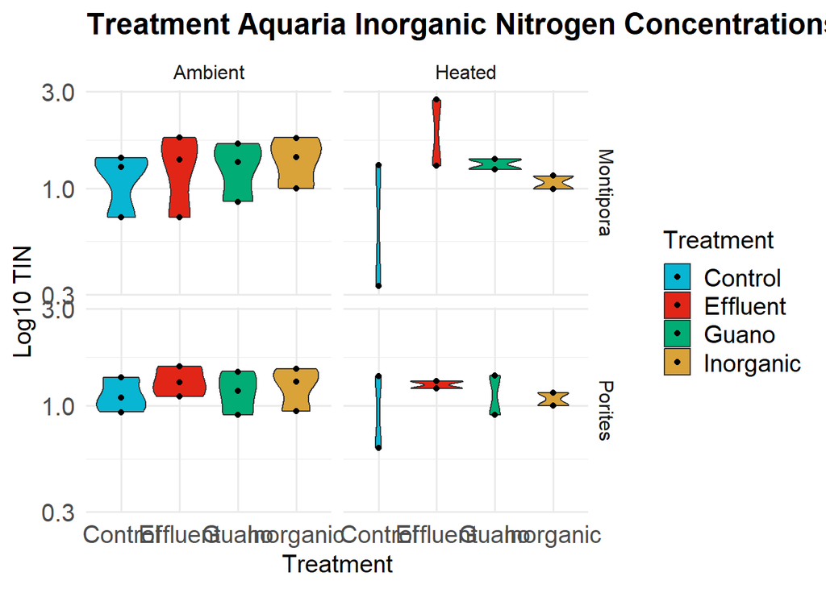

```r
# Violin Plot - TIN pooled at all timepoints
ggplot(data=subset(nuts, Tank %in% c("Aquaria")), aes(x=Treatment, y=TIN, fill=Treatment))+
  geom_violin()+
  facet_grid(Species ~ Temperature) +
  geom_jitter(width=0)+
  ggtitle("Treatment Aquaria Inorganic Nitrogen Concentrations")+
  scale_fill_manual(values=naste_colors)+
  scale_y_continuous(trans = "log10", name = "Log10 TIN")
```

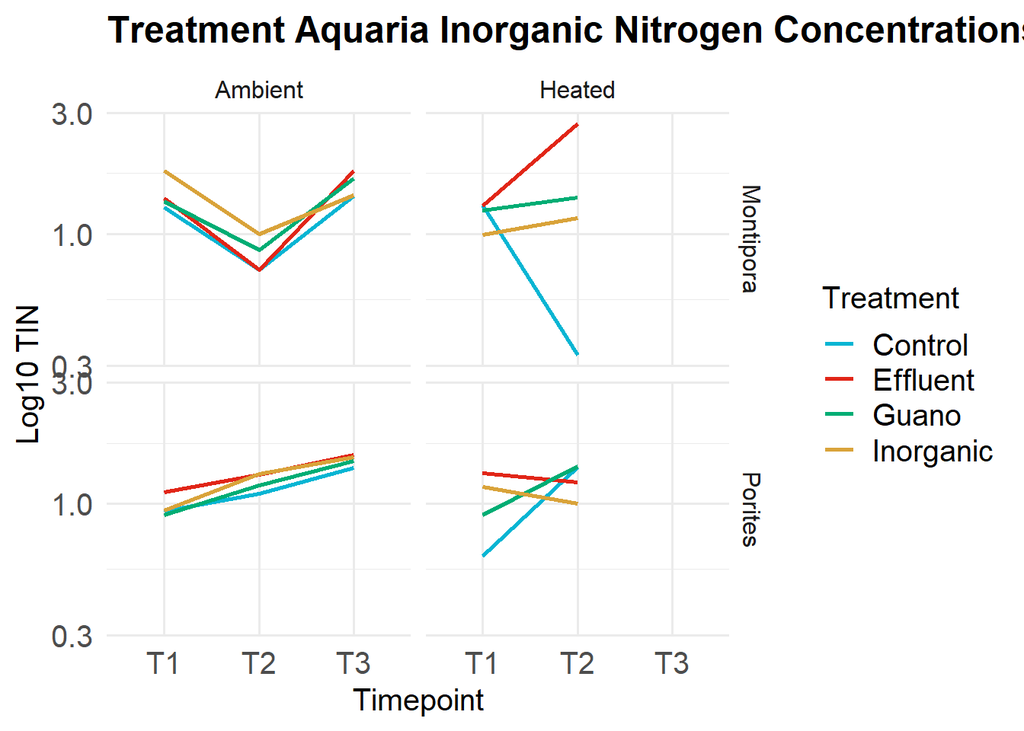

```r
# Line Plot - to show time series of TIN
ggplot(data=subset(nuts, Tank %in% c("Aquaria")), aes(x=Timepoint, y=TIN, group=Treatment, color=Treatment))+
  geom_line(size=1)+
  facet_grid(Species ~ Temperature)+
  ggtitle("Treatment Aquaria Inorganic Nitrogen Concentrations")+
  scale_color_manual(values= naste_colors)+
  scale_y_continuous(trans = "log10", name = "Log10 TIN")
```

### Analysis of TIN in aquaria - LME

```r
# Pooled Montipora and Porites
TIN_aquaria <- nuts %>%
  filter(Tank == "Aquaria") %>%
  lmer(log10(TIN) ~ Treatment * Timepoint + (1|Aquaria), data = .)
```

```
## boundary (singular) fit: see help('isSingular')
```

```r
summary(TIN_aquaria)
```

```
## Linear mixed model fit by REML ['lmerMod']
## Formula: log10(TIN) ~ Treatment * Timepoint + (1 | Aquaria)
##    Data: .
##
## REML criterion at convergence: -15.2
##
## Scaled residuals:
##      Min       1Q   Median       3Q      Max
## -2.57257 -0.30888 -0.02315  0.43848  2.16889
##
## Random effects:
##  Groups   Name        Variance Std.Dev.
##  Aquaria  (Intercept) 0.00000  0.000
##  Residual             0.02075  0.144
## Number of obs: 40, groups:  Aquaria, 16
##
## Fixed effects:
##                                 Estimate Std. Error t value
## (Intercept)                    -0.005345   0.072021  -0.074
## TreatmentEffluent               0.109436   0.101853   1.074
## TreatmentGuano                  0.037597   0.101853   0.369
## TreatmentInorganic              0.075643   0.101853   0.743
## TimepointT2                    -0.105583   0.101853  -1.037
## TimepointT3                     0.149894   0.124744   1.202
## TreatmentEffluent:TimepointT2   0.123650   0.144042   0.858
## TreatmentGuano:TimepointT2      0.147211   0.144042   1.022
## TreatmentInorganic:TimepointT2  0.079777   0.144042   0.554
## TreatmentEffluent:TimepointT3  -0.032213   0.176415  -0.183
## TreatmentGuano:TimepointT3      0.011566   0.176415   0.066
## TreatmentInorganic:TimepointT3 -0.053126   0.176415  -0.301
##
## Correlation of Fixed Effects:
##             (Intr) TrtmnE TrtmnG TrtmnI TmpnT2 TmpnT3 TE:TT2 TG:TT2 TI:TT2
## TrtmntEffln -0.707
## TreatmentGn -0.707  0.500
## TrtmntInrgn -0.707  0.500  0.500
## TimepointT2 -0.707  0.500  0.500  0.500
## TimepointT3 -0.577  0.408  0.408  0.408  0.408
## TrtmntE:TT2  0.500 -0.707 -0.354 -0.354 -0.707 -0.289
## TrtmntG:TT2  0.500 -0.354 -0.707 -0.354 -0.707 -0.289  0.500
## TrtmntI:TT2  0.500 -0.354 -0.354 -0.707 -0.707 -0.289  0.500  0.500
## TrtmntE:TT3  0.408 -0.577 -0.289 -0.289 -0.289 -0.707  0.408  0.204  0.204
## TrtmntG:TT3  0.408 -0.289 -0.577 -0.289 -0.289 -0.707  0.204  0.408  0.204
## TrtmntI:TT3  0.408 -0.289 -0.289 -0.577 -0.289 -0.707  0.204  0.204  0.408
##             TE:TT3 TG:TT3
## TrtmntEffln
## TreatmentGn
## TrtmntInrgn
## TimepointT2
## TimepointT3
## TrtmntE:TT2
## TrtmntG:TT2
## TrtmntI:TT2
## TrtmntE:TT3
## TrtmntG:TT3  0.500
## TrtmntI:TT3  0.500  0.500
## optimizer (nloptwrap) convergence code: 0 (OK)
## boundary (singular) fit: see help('isSingular')
```

```r
emm_tin_a<- emmeans(TIN_aquaria, ~ Treatment)
```

```
## NOTE: Results may be misleading due to involvement in interactions
```

```r
emm_tin_a
```

```
##  Treatment  emmean     SE   df lower.CL upper.CL
##  Control   0.00943 0.0492 10.9 -0.09902    0.118
##  Effluent  0.14934 0.0492 10.9  0.04090    0.258
##  Guano     0.09995 0.0492 10.9 -0.00849    0.208
##  Inorganic 0.09395 0.0492 10.9 -0.01449    0.202
##
## Results are averaged over the levels of: Timepoint
## Degrees-of-freedom method: kenward-roger
## Results are given on the log10 (not the response) scale.
## Confidence level used: 0.95
```

```r
pair_tin_a<- contrast(emm_tin_a, method='pairwise')
summary(pair_tin_a)
```

```
##  contrast             estimate     SE   df t.ratio p.value
##  Control - Effluent    -0.1399 0.0696 10.9  -2.011  0.2423
##  Control - Guano       -0.0905 0.0696 10.9  -1.301  0.5811
##  Control - Inorganic   -0.0845 0.0696 10.9  -1.215  0.6309
##  Effluent - Guano       0.0494 0.0696 10.9   0.710  0.8911
##  Effluent - Inorganic   0.0554 0.0696 10.9   0.796  0.8548
##  Guano - Inorganic      0.0060 0.0696 10.9   0.086  0.9998
##
## Results are averaged over the levels of: Timepoint
## Degrees-of-freedom method: kenward-roger
## Results are given on the log10 (not the response) scale.
## P value adjustment: tukey method for comparing a family of 4 estimates
```

```r
# no differences across treatments through time - indicates all tanks drew down TIN to same level

# Montipora
TIN_aquaria_m <- mc_nuts %>%
  filter(Tank == "Aquaria") %>%
  lmer(log10(TIN) ~ Treatment * Timepoint + (1|Aquaria), data = .)
```

```
## boundary (singular) fit: see help('isSingular')
```

```r
summary(TIN_aquaria_m)
```

```
## Linear mixed model fit by REML ['lmerMod']
## Formula: log10(TIN) ~ Treatment * Timepoint + (1 | Aquaria)
##    Data: .
##
## REML criterion at convergence: 1.4
##
## Scaled residuals:
##    Min     1Q Median     3Q    Max
## -1.541 -0.108  0.000  0.108  1.541
##
## Random effects:
##  Groups   Name        Variance Std.Dev.
##  Aquaria  (Intercept) 0.00000  0.0000
##  Residual             0.03506  0.1872
## Number of obs: 20, groups:  Aquaria, 8
##
## Fixed effects:
##                                 Estimate Std. Error t value
## (Intercept)                     0.108874   0.132398   0.822
## TreatmentEffluent               0.016361   0.187239   0.087
## TreatmentGuano                  0.001390   0.187239   0.007
## TreatmentInorganic              0.012931   0.187239   0.069
## TimepointT2                    -0.420950   0.187239  -2.248
## TimepointT3                     0.040346   0.229320   0.176
## TreatmentEffluent:TimepointT2   0.441667   0.264795   1.668
## TreatmentGuano:TimepointT2      0.349444   0.264795   1.320
## TreatmentInorganic:TimepointT2  0.329495   0.264795   1.244
## TreatmentEffluent:TimepointT3   0.084840   0.324307   0.262
## TreatmentGuano:TimepointT3      0.069499   0.324307   0.214
## TreatmentInorganic:TimepointT3 -0.009861   0.324307  -0.030
##
## Correlation of Fixed Effects:
##             (Intr) TrtmnE TrtmnG TrtmnI TmpnT2 TmpnT3 TE:TT2 TG:TT2 TI:TT2
## TrtmntEffln -0.707
## TreatmentGn -0.707  0.500
## TrtmntInrgn -0.707  0.500  0.500
## TimepointT2 -0.707  0.500  0.500  0.500
## TimepointT3 -0.577  0.408  0.408  0.408  0.408
## TrtmntE:TT2  0.500 -0.707 -0.354 -0.354 -0.707 -0.289
## TrtmntG:TT2  0.500 -0.354 -0.707 -0.354 -0.707 -0.289  0.500
## TrtmntI:TT2  0.500 -0.354 -0.354 -0.707 -0.707 -0.289  0.500  0.500
## TrtmntE:TT3  0.408 -0.577 -0.289 -0.289 -0.289 -0.707  0.408  0.204  0.204
## TrtmntG:TT3  0.408 -0.289 -0.577 -0.289 -0.289 -0.707  0.204  0.408  0.204
## TrtmntI:TT3  0.408 -0.289 -0.289 -0.577 -0.289 -0.707  0.204  0.204  0.408
##             TE:TT3 TG:TT3
## TrtmntEffln
## TreatmentGn
## TrtmntInrgn
## TimepointT2
## TimepointT3
## TrtmntE:TT2
## TrtmntG:TT2
## TrtmntI:TT2
## TrtmntE:TT3
## TrtmntG:TT3  0.500
## TrtmntI:TT3  0.500  0.500
## optimizer (nloptwrap) convergence code: 0 (OK)
## boundary (singular) fit: see help('isSingular')
```

```r
emm_tin_a_m<- emmeans(TIN_aquaria_m, ~ Treatment)
```

```
## NOTE: Results may be misleading due to involvement in interactions
```

```r
emm_tin_a_m
```

```
##  Treatment emmean     SE   df lower.CL upper.CL
##  Control   -0.018 0.0987 2.46   -0.375    0.339
##  Effluent   0.174 0.0987 2.46   -0.183    0.531
##  Guano      0.123 0.0987 2.46   -0.234    0.480
##  Inorganic  0.101 0.0987 2.46   -0.255    0.458
##
## Results are averaged over the levels of: Timepoint
## Degrees-of-freedom method: kenward-roger
## Results are given on the log10 (not the response) scale.
## Confidence level used: 0.95
```

```r
pair_tin_a_m<- contrast(emm_tin_a_m, method='pairwise')
summary(pair_tin_a_m)
```

```
##  contrast             estimate   SE   df t.ratio p.value
##  Control - Effluent    -0.1919 0.14 2.46  -1.375  0.5975
##  Control - Guano       -0.1410 0.14 2.46  -1.011  0.7598
##  Control - Inorganic   -0.1195 0.14 2.46  -0.856  0.8282
##  Effluent - Guano       0.0508 0.14 2.46   0.364  0.9801
##  Effluent - Inorganic   0.0724 0.14 2.46   0.519  0.9482
##  Guano - Inorganic      0.0216 0.14 2.46   0.155  0.9983
##
## Results are averaged over the levels of: Timepoint
## Degrees-of-freedom method: kenward-roger
## Results are given on the log10 (not the response) scale.
## P value adjustment: tukey method for comparing a family of 4 estimates
```

```r
# no differences across treatments through time - indicates all tanks drew down TIN to same level


TIN_aquaria_p <- pc_nuts %>%
  filter(Tank == "Aquaria") %>%
  lmer(log10(TIN) ~ Treatment * Timepoint + (1|Aquaria), data = .)
```

```
## boundary (singular) fit: see help('isSingular')
```

```r
summary(TIN_aquaria_p)
```

```
## Linear mixed model fit by REML ['lmerMod']
## Formula: log10(TIN) ~ Treatment * Timepoint + (1 | Aquaria)
##    Data: .
##
## REML criterion at convergence: -14.5
##
## Scaled residuals:
##     Min      1Q  Median      3Q     Max
## -1.2742 -0.5391  0.0000  0.5391  1.2742
##
## Random effects:
##  Groups   Name        Variance Std.Dev.
##  Aquaria  (Intercept) 0.000000 0.0000
##  Residual             0.004775 0.0691
## Number of obs: 20, groups:  Aquaria, 8
##
## Fixed effects:
##                                Estimate Std. Error t value
## (Intercept)                    -0.11956    0.04886  -2.447
## TreatmentEffluent               0.20251    0.06910   2.931
## TreatmentGuano                  0.07381    0.06910   1.068
## TreatmentInorganic              0.13836    0.06910   2.002
## TimepointT2                     0.20978    0.06910   3.036
## TimepointT3                     0.25944    0.08463   3.066
## TreatmentEffluent:TimepointT2  -0.19437    0.09772  -1.989
## TreatmentGuano:TimepointT2     -0.05502    0.09772  -0.563
## TreatmentInorganic:TimepointT2 -0.16994    0.09772  -1.739
## TreatmentEffluent:TimepointT3  -0.14927    0.11968  -1.247
## TreatmentGuano:TimepointT3     -0.04637    0.11968  -0.387
## TreatmentInorganic:TimepointT3 -0.09639    0.11968  -0.805
##
## Correlation of Fixed Effects:
##             (Intr) TrtmnE TrtmnG TrtmnI TmpnT2 TmpnT3 TE:TT2 TG:TT2 TI:TT2
## TrtmntEffln -0.707
## TreatmentGn -0.707  0.500
## TrtmntInrgn -0.707  0.500  0.500
## TimepointT2 -0.707  0.500  0.500  0.500
## TimepointT3 -0.577  0.408  0.408  0.408  0.408
## TrtmntE:TT2  0.500 -0.707 -0.354 -0.354 -0.707 -0.289
## TrtmntG:TT2  0.500 -0.354 -0.707 -0.354 -0.707 -0.289  0.500
## TrtmntI:TT2  0.500 -0.354 -0.354 -0.707 -0.707 -0.289  0.500  0.500
## TrtmntE:TT3  0.408 -0.577 -0.289 -0.289 -0.289 -0.707  0.408  0.204  0.204
## TrtmntG:TT3  0.408 -0.289 -0.577 -0.289 -0.289 -0.707  0.204  0.408  0.204
## TrtmntI:TT3  0.408 -0.289 -0.289 -0.577 -0.289 -0.707  0.204  0.204  0.408
##             TE:TT3 TG:TT3
## TrtmntEffln
## TreatmentGn
## TrtmntInrgn
## TimepointT2
## TimepointT3
## TrtmntE:TT2
## TrtmntG:TT2
## TrtmntI:TT2
## TrtmntE:TT3
## TrtmntG:TT3  0.500
## TrtmntI:TT3  0.500  0.500
## optimizer (nloptwrap) convergence code: 0 (OK)
## boundary (singular) fit: see help('isSingular')
```

```r
emm_tin_a_p<- emmeans(TIN_aquaria_p, ~ Treatment)
```

```
## NOTE: Results may be misleading due to involvement in interactions
```

```r
emm_tin_a_p
```

```
##  Treatment emmean     SE   df lower.CL upper.CL
##  Control   0.0368 0.0364 2.46 -0.09481    0.168
##  Effluent  0.1248 0.0364 2.46 -0.00684    0.256
##  Guano     0.0769 0.0364 2.46 -0.05480    0.209
##  Inorganic 0.0864 0.0364 2.46 -0.04523    0.218
##
## Results are averaged over the levels of: Timepoint
## Degrees-of-freedom method: kenward-roger
## Results are given on the log10 (not the response) scale.
## Confidence level used: 0.95
```

```r
pair_tin_a_p<- contrast(emm_tin_a_p, method='pairwise')
summary(pair_tin_a_p)
```

```
##  contrast             estimate     SE   df t.ratio p.value
##  Control - Effluent   -0.08797 0.0515 2.46  -1.708  0.4690
##  Control - Guano      -0.04001 0.0515 2.46  -0.777  0.8611
##  Control - Inorganic  -0.04958 0.0515 2.46  -0.963  0.7815
##  Effluent - Guano      0.04796 0.0515 2.46   0.931  0.7955
##  Effluent - Inorganic  0.03839 0.0515 2.46   0.745  0.8735
##  Guano - Inorganic    -0.00957 0.0515 2.46  -0.186  0.9971
##
## Results are averaged over the levels of: Timepoint
## Degrees-of-freedom method: kenward-roger
## Results are given on the log10 (not the response) scale.
## P value adjustment: tukey method for comparing a family of 4 estimates
```

```r
# no differences across treatments through time - indicates all tanks drew down TIN to same level

# Pooled and separated data have same results
```

# N+N

## Dosing

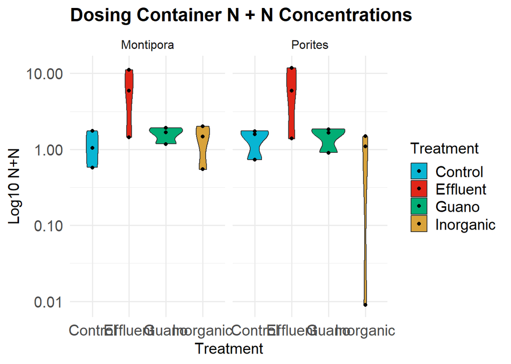

```r
# Violin Plot - N+N pooled at all timepoints
ggplot(data=subset(nuts, Tank %in% c("Dosing")), aes(x=Treatment, y=N.N, fill=Treatment))+
  geom_violin()+
  facet_wrap(~Species) +
  geom_jitter(width=0)+
  ggtitle("Dosing Container N + N Concentrations")+
  scale_fill_manual(values=naste_colors)+
  scale_y_continuous(trans = "log10", name = "Log10 N+N")
```

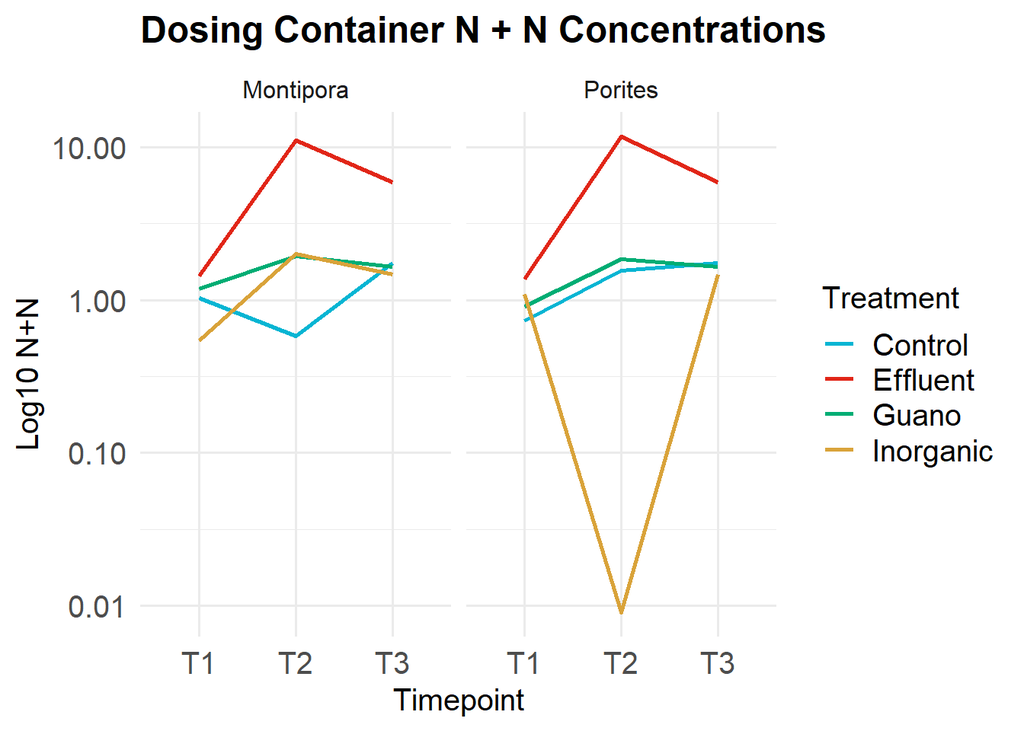

```r
# Line Plot - to show time series of N+N
ggplot(data=subset(nuts, Tank %in% c("Dosing")), aes(x=Timepoint, y=N.N, group=Treatment, color=Treatment))+
  geom_line(size = 1)+
  facet_wrap(~Species)+
  ggtitle("Dosing Container N + N Concentrations")+
  scale_color_manual(values= naste_colors)+
  scale_y_continuous(trans = "log10", name = "Log10 N+N")
```

### Analysis of N+N in Dosing - linear model

```r
# Pooled Montipora and Porites together
N.N_dosing <- nuts %>%
  filter(Tank == "Dosing") %>%
  lm(log10(N.N) ~ Treatment, data = .)
summary(N.N_dosing)
```

```
##
## Call:
## lm(formula = log10(N.N) ~ Treatment, data = .)
##
## Residuals:
##     Min      1Q  Median      3Q     Max
## -1.7734 -0.1218  0.1053  0.2199  0.5734
##
## Coefficients:
##                    Estimate Std. Error t value Pr(>|t|)
## (Intercept)         0.05313    0.20663   0.257   0.7997
## TreatmentEffluent   0.60708    0.29222   2.077   0.0509 .
## TreatmentGuano      0.11790    0.29222   0.403   0.6909
## TreatmentInorganic -0.32553    0.29222  -1.114   0.2785
## ---
## Signif. codes:  0 '***' 0.001 '**' 0.01 '*' 0.05 '.' 0.1 ' ' 1
##
## Residual standard error: 0.5061 on 20 degrees of freedom
## Multiple R-squared:  0.3444, Adjusted R-squared:  0.246
## F-statistic: 3.502 on 3 and 20 DF,  p-value: 0.03444
```

```r
emm_nn<- emmeans(N.N_dosing, ~ Treatment)
emm_nn
```

```
##  Treatment  emmean    SE df lower.CL upper.CL
##  Control    0.0531 0.207 20   -0.378    0.484
##  Effluent   0.6602 0.207 20    0.229    1.091
##  Guano      0.1710 0.207 20   -0.260    0.602
##  Inorganic -0.2724 0.207 20   -0.703    0.159
##
## Results are given on the log10 (not the response) scale.
## Confidence level used: 0.95
```

```r
pair_nn<- contrast(emm_nn, method='pairwise')
summary(pair_nn)
```

```
##  contrast             estimate    SE df t.ratio p.value
##  Control - Effluent     -0.607 0.292 20  -2.077  0.1945
##  Control - Guano        -0.118 0.292 20  -0.403  0.9772
##  Control - Inorganic     0.326 0.292 20   1.114  0.6854
##  Effluent - Guano        0.489 0.292 20   1.674  0.3627
##  Effluent - Inorganic    0.933 0.292 20   3.191  0.0219
##  Guano - Inorganic       0.443 0.292 20   1.517  0.4462
##
## Results are given on the log10 (not the response) scale.
## P value adjustment: tukey method for comparing a family of 4 estimates
```

```r
# Effluent different from inorganic, similar to control and guano. Other 3 treatments are similar.

# Montipora
N.N_dosing_m <- mc_nuts %>%
  filter(Tank == "Dosing") %>%
  lm(log10(N.N) ~ Treatment, data = .)
summary(N.N_dosing_m)
```

```
##
## Call:
## lm(formula = log10(N.N) ~ Treatment, data = .)
##
## Residuals:
##      Min       1Q   Median       3Q      Max
## -0.50057 -0.15123  0.06032  0.14333  0.38718
##
## Coefficients:
##                    Estimate Std. Error t value Pr(>|t|)
## (Intercept)        0.006434   0.174376   0.037   0.9715
## TreatmentEffluent  0.652495   0.246605   2.646   0.0294 *
## TreatmentGuano     0.186081   0.246605   0.755   0.4721
## TreatmentInorganic 0.061461   0.246605   0.249   0.8095
## ---
## Signif. codes:  0 '***' 0.001 '**' 0.01 '*' 0.05 '.' 0.1 ' ' 1
##
## Residual standard error: 0.302 on 8 degrees of freedom
## Multiple R-squared:  0.5182, Adjusted R-squared:  0.3375
## F-statistic: 2.868 on 3 and 8 DF,  p-value: 0.1038
```

```r
emm_nn_m<- emmeans(N.N_dosing_m, ~ Treatment)
emm_nn_m
```

```
##  Treatment  emmean    SE df lower.CL upper.CL
##  Control   0.00643 0.174  8   -0.396    0.409
##  Effluent  0.65893 0.174  8    0.257    1.061
##  Guano     0.19252 0.174  8   -0.210    0.595
##  Inorganic 0.06790 0.174  8   -0.334    0.470
##
## Results are given on the log10 (not the response) scale.
## Confidence level used: 0.95
```

```r
pair_nn_m<- contrast(emm_nn_m, method='pairwise')
summary(pair_nn_m)
```

```
##  contrast             estimate    SE df t.ratio p.value
##  Control - Effluent    -0.6525 0.247  8  -2.646  0.1096
##  Control - Guano       -0.1861 0.247  8  -0.755  0.8723
##  Control - Inorganic   -0.0615 0.247  8  -0.249  0.9941
##  Effluent - Guano       0.4664 0.247  8   1.891  0.3033
##  Effluent - Inorganic   0.5910 0.247  8   2.397  0.1551
##  Guano - Inorganic      0.1246 0.247  8   0.505  0.9555
##
## Results are given on the log10 (not the response) scale.
## P value adjustment: tukey method for comparing a family of 4 estimates
```

```r
# Effluent comes up different in model summary but not in post-hoc comparison. Everything else similar

# Porites
N.N_dosing_p <- pc_nuts %>%
  filter(Tank == "Dosing") %>%
  lm(log10(N.N) ~ Treatment, data = .)
summary(N.N_dosing_p)
```

```
##
## Call:
## lm(formula = log10(N.N) ~ Treatment, data = .)
##
## Residuals:
##     Min      1Q  Median      3Q     Max
## -1.4331 -0.2020  0.1021  0.2101  0.7830
##
## Coefficients:
##                    Estimate Std. Error t value Pr(>|t|)
## (Intercept)         0.09983    0.39175   0.255    0.805
## TreatmentEffluent   0.56166    0.55402   1.014    0.340
## TreatmentGuano      0.04973    0.55402   0.090    0.931
## TreatmentInorganic -0.71252    0.55402  -1.286    0.234
##
## Residual standard error: 0.6785 on 8 degrees of freedom
## Multiple R-squared:  0.4013, Adjusted R-squared:  0.1768
## F-statistic: 1.788 on 3 and 8 DF,  p-value: 0.2272
```

```r
emm_nn_p<- emmeans(N.N_dosing_p, ~ Treatment)
emm_nn_p
```

```
##  Treatment  emmean    SE df lower.CL upper.CL
##  Control    0.0998 0.392  8   -0.804    1.003
##  Effluent   0.6615 0.392  8   -0.242    1.565
##  Guano      0.1496 0.392  8   -0.754    1.053
##  Inorganic -0.6127 0.392  8   -1.516    0.291
##
## Results are given on the log10 (not the response) scale.
## Confidence level used: 0.95
```

```r
pair_nn_p<- contrast(emm_nn_p, method='pairwise')
summary(pair_nn_p)
```

```
##  contrast             estimate    SE df t.ratio p.value
##  Control - Effluent    -0.5617 0.554  8  -1.014  0.7465
##  Control - Guano       -0.0497 0.554  8  -0.090  0.9997
##  Control - Inorganic    0.7125 0.554  8   1.286  0.5955
##  Effluent - Guano       0.5119 0.554  8   0.924  0.7933
##  Effluent - Inorganic   1.2742 0.554  8   2.300  0.1771
##  Guano - Inorganic      0.7622 0.554  8   1.376  0.5460
##
## Results are given on the log10 (not the response) scale.
## P value adjustment: tukey method for comparing a family of 4 estimates
```

```r
# All treatments similar.


# The Montipora effluent dosing container is significantly different in model but not in emmeans post hoc test. Otherwise, pooled and separated data is the same.
```

### Treatment Aquaria

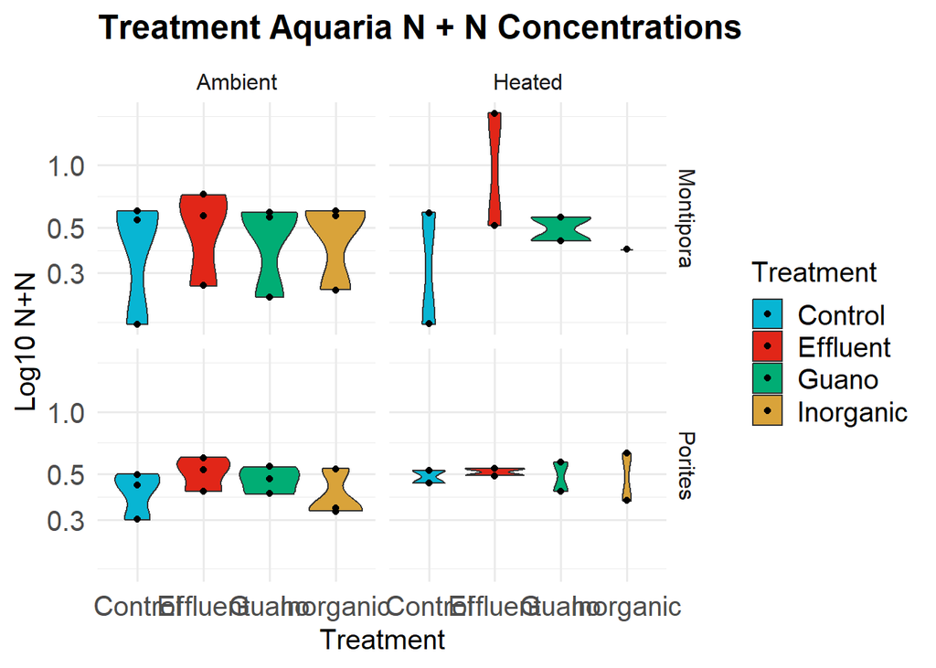

```r
# Violin Plot - N + N pooled at all timepoints
ggplot(data=subset(nuts, Tank %in% c("Aquaria")), aes(x=Treatment, y=N.N, fill=Treatment))+
  geom_violin()+
  facet_grid(Species ~ Temperature) +
  geom_jitter(width=0)+
  ggtitle("Treatment Aquaria N + N Concentrations")+
  scale_fill_manual(values=naste_colors)+
  scale_y_continuous(trans = "log10", name = "Log10 N+N")
```

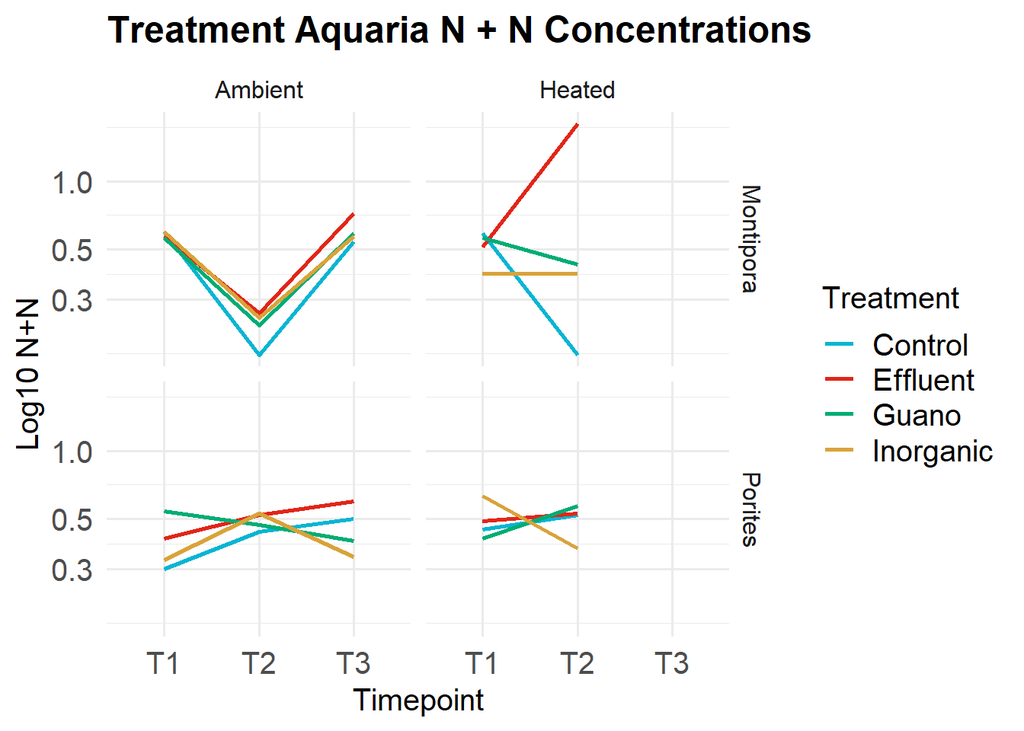

```r
# Line Plot - to show time series of N + N
ggplot(data=subset(nuts, Tank %in% c("Aquaria")), aes(x=Timepoint, y=N.N, group=Treatment, color=Treatment))+
  geom_line(size = 1)+
  facet_grid(Species ~ Temperature)+
  ggtitle("Treatment Aquaria N + N Concentrations")+
  scale_color_manual(values= naste_colors)+
  scale_y_continuous(trans = "log10", name = "Log10 N+N")
```

### Analysis of N+N in aquaria - LME

```r
# Pooled Montipora and Porites
N.N_aquaria <- nuts %>%
  filter(Tank == "Aquaria") %>%
  lmer(log10(N.N) ~ Treatment * Timepoint + (1|Aquaria), data = .)
```

```
## boundary (singular) fit: see help('isSingular')
```

```r
summary(N.N_aquaria)
```

```
## Linear mixed model fit by REML ['lmerMod']
## Formula: log10(N.N) ~ Treatment * Timepoint + (1 | Aquaria)
##    Data: .
##
## REML criterion at convergence: -3.1
##
## Scaled residuals:
##      Min       1Q   Median       3Q      Max
## -2.02720 -0.45704  0.09148  0.49582  2.66424
##
## Random effects:
##  Groups   Name        Variance Std.Dev.
##  Aquaria  (Intercept) 0.0000   0.0000
##  Residual             0.0319   0.1786
## Number of obs: 40, groups:  Aquaria, 16
##
## Fixed effects:
##                                 Estimate Std. Error t value
## (Intercept)                    -0.330166   0.089299  -3.697
## TreatmentEffluent               0.021772   0.126288   0.172
## TreatmentGuano                  0.040554   0.126288   0.321
## TreatmentInorganic              0.001933   0.126288   0.015
## TimepointT2                    -0.214746   0.126288  -1.700
## TimepointT3                     0.045848   0.154670   0.296
## TreatmentEffluent:TimepointT2   0.300166   0.178598   1.681
## TreatmentGuano:TimepointT2      0.110150   0.178598   0.617
## TreatmentInorganic:TimepointT2  0.113349   0.178598   0.635
## TreatmentEffluent:TimepointT3   0.080288   0.218736   0.367
## TreatmentGuano:TimepointT3     -0.069780   0.218736  -0.319
## TreatmentInorganic:TimepointT3 -0.073938   0.218736  -0.338
##
## Correlation of Fixed Effects:
##             (Intr) TrtmnE TrtmnG TrtmnI TmpnT2 TmpnT3 TE:TT2 TG:TT2 TI:TT2
## TrtmntEffln -0.707
## TreatmentGn -0.707  0.500
## TrtmntInrgn -0.707  0.500  0.500
## TimepointT2 -0.707  0.500  0.500  0.500
## TimepointT3 -0.577  0.408  0.408  0.408  0.408
## TrtmntE:TT2  0.500 -0.707 -0.354 -0.354 -0.707 -0.289
## TrtmntG:TT2  0.500 -0.354 -0.707 -0.354 -0.707 -0.289  0.500
## TrtmntI:TT2  0.500 -0.354 -0.354 -0.707 -0.707 -0.289  0.500  0.500
## TrtmntE:TT3  0.408 -0.577 -0.289 -0.289 -0.289 -0.707  0.408  0.204  0.204
## TrtmntG:TT3  0.408 -0.289 -0.577 -0.289 -0.289 -0.707  0.204  0.408  0.204
## TrtmntI:TT3  0.408 -0.289 -0.289 -0.577 -0.289 -0.707  0.204  0.204  0.408
##             TE:TT3 TG:TT3
## TrtmntEffln
## TreatmentGn
## TrtmntInrgn
## TimepointT2
## TimepointT3
## TrtmntE:TT2
## TrtmntG:TT2
## TrtmntI:TT2
## TrtmntE:TT3
## TrtmntG:TT3  0.500
## TrtmntI:TT3  0.500  0.500
## optimizer (nloptwrap) convergence code: 0 (OK)
## boundary (singular) fit: see help('isSingular')
```

```r
emm_nn_a<- emmeans(N.N_aquaria, ~ Treatment)
```

```
## NOTE: Results may be misleading due to involvement in interactions
```

```r
emm_nn_a
```

```
##  Treatment emmean    SE   df lower.CL upper.CL
##  Control   -0.386 0.061 10.9   -0.521   -0.252
##  Effluent  -0.238 0.061 10.9   -0.372   -0.103
##  Guano     -0.332 0.061 10.9   -0.467   -0.198
##  Inorganic -0.371 0.061 10.9   -0.506   -0.237
##
## Results are averaged over the levels of: Timepoint
## Degrees-of-freedom method: kenward-roger
## Results are given on the log10 (not the response) scale.
## Confidence level used: 0.95
```

```r
pair_nn_a<- contrast(emm_nn_a, method='pairwise')
summary(pair_nn_a)
```

```
##  contrast             estimate     SE   df t.ratio p.value
##  Control - Effluent    -0.1486 0.0863 10.9  -1.722  0.3587
##  Control - Guano       -0.0540 0.0863 10.9  -0.626  0.9215
##  Control - Inorganic   -0.0151 0.0863 10.9  -0.175  0.9980
##  Effluent - Guano       0.0946 0.0863 10.9   1.096  0.6990
##  Effluent - Inorganic   0.1335 0.0863 10.9   1.548  0.4447
##  Guano - Inorganic      0.0389 0.0863 10.9   0.451  0.9680
##
## Results are averaged over the levels of: Timepoint
## Degrees-of-freedom method: kenward-roger
## Results are given on the log10 (not the response) scale.
## P value adjustment: tukey method for comparing a family of 4 estimates
```

```r
# no differences across treatments through time - indicates all tanks drew down N+N to same level

# Montipora
N.N_aquaria_m <- mc_nuts %>%
  filter(Tank == "Aquaria") %>%
  lmer(log10(N.N) ~ Treatment * Timepoint + (1|Aquaria), data = .)
```

```
## boundary (singular) fit: see help('isSingular')
```

```r
summary(N.N_aquaria_m)
```

```
## Linear mixed model fit by REML ['lmerMod']
## Formula: log10(N.N) ~ Treatment * Timepoint + (1 | Aquaria)
##    Data: .
##
## REML criterion at convergence: 4.8
##
## Scaled residuals:
##      Min       1Q   Median       3Q      Max
## -1.81701 -0.03806  0.00000  0.03806  1.81701
##
## Random effects:
##  Groups   Name        Variance Std.Dev.
##  Aquaria  (Intercept) 0.00000  0.0000
##  Residual             0.05316  0.2306
## Number of obs: 20, groups:  Aquaria, 8
##
## Fixed effects:
##                                Estimate Std. Error t value
## (Intercept)                    -0.22550    0.16303  -1.383
## TreatmentEffluent              -0.04278    0.23057  -0.186
## TreatmentGuano                 -0.02631    0.23057  -0.114
## TreatmentInorganic             -0.08989    0.23057  -0.390
## TimepointT2                    -0.54405    0.23057  -2.360
## TimepointT3                    -0.04211    0.28238  -0.149
## TreatmentEffluent:TimepointT2   0.64624    0.32607   1.982
## TreatmentGuano:TimepointT2      0.29346    0.32607   0.900
## TreatmentInorganic:TimepointT2  0.35395    0.32607   1.085
## TreatmentEffluent:TimepointT3   0.16772    0.39935   0.420
## TreatmentGuano:TimepointT3      0.06477    0.39935   0.162
## TreatmentInorganic:TimepointT3  0.11337    0.39935   0.284
##
## Correlation of Fixed Effects:
##             (Intr) TrtmnE TrtmnG TrtmnI TmpnT2 TmpnT3 TE:TT2 TG:TT2 TI:TT2
## TrtmntEffln -0.707
## TreatmentGn -0.707  0.500
## TrtmntInrgn -0.707  0.500  0.500
## TimepointT2 -0.707  0.500  0.500  0.500
## TimepointT3 -0.577  0.408  0.408  0.408  0.408
## TrtmntE:TT2  0.500 -0.707 -0.354 -0.354 -0.707 -0.289
## TrtmntG:TT2  0.500 -0.354 -0.707 -0.354 -0.707 -0.289  0.500
## TrtmntI:TT2  0.500 -0.354 -0.354 -0.707 -0.707 -0.289  0.500  0.500
## TrtmntE:TT3  0.408 -0.577 -0.289 -0.289 -0.289 -0.707  0.408  0.204  0.204
## TrtmntG:TT3  0.408 -0.289 -0.577 -0.289 -0.289 -0.707  0.204  0.408  0.204
## TrtmntI:TT3  0.408 -0.289 -0.289 -0.577 -0.289 -0.707  0.204  0.204  0.408
##             TE:TT3 TG:TT3
## TrtmntEffln
## TreatmentGn
## TrtmntInrgn
## TimepointT2
## TimepointT3
## TrtmntE:TT2
## TrtmntG:TT2
## TrtmntI:TT2
## TrtmntE:TT3
## TrtmntG:TT3  0.500
## TrtmntI:TT3  0.500  0.500
## optimizer (nloptwrap) convergence code: 0 (OK)
## boundary (singular) fit: see help('isSingular')
```

```r
emm_nn_a_m<- emmeans(N.N_aquaria_m, ~ Treatment)
```

```
## NOTE: Results may be misleading due to involvement in interactions
```

```r
emm_nn_a_m
```

```
##  Treatment emmean    SE   df lower.CL upper.CL
##  Control   -0.421 0.122 2.46   -0.860   0.0184
##  Effluent  -0.192 0.122 2.46   -0.632   0.2469
##  Guano     -0.328 0.122 2.46   -0.767   0.1115
##  Inorganic -0.355 0.122 2.46   -0.794   0.0843
##
## Results are averaged over the levels of: Timepoint
## Degrees-of-freedom method: kenward-roger
## Results are given on the log10 (not the response) scale.
## Confidence level used: 0.95
```

```r
pair_nn_a_m<- contrast(emm_nn_a_m, method='pairwise')
summary(pair_nn_a_m)
```

```
##  contrast             estimate    SE   df t.ratio p.value
##  Control - Effluent    -0.2285 0.172 2.46  -1.330  0.6167
##  Control - Guano       -0.0931 0.172 2.46  -0.542  0.9420
##  Control - Inorganic   -0.0659 0.172 2.46  -0.383  0.9771
##  Effluent - Guano       0.1354 0.172 2.46   0.788  0.8565
##  Effluent - Inorganic   0.1627 0.172 2.46   0.947  0.7887
##  Guano - Inorganic      0.0272 0.172 2.46   0.158  0.9982
##
## Results are averaged over the levels of: Timepoint
## Degrees-of-freedom method: kenward-roger
## Results are given on the log10 (not the response) scale.
## P value adjustment: tukey method for comparing a family of 4 estimates
```

```r
# no differences across treatments through time - indicates all tanks drew down N+N to same level

# Porites
N.N_aquaria_p <- pc_nuts %>%
  filter(Tank == "Aquaria") %>%
  lmer(log10(N.N) ~ Treatment * Timepoint + (1|Aquaria), data = .)
```

```
## boundary (singular) fit: see help('isSingular')
```

```r
summary(N.N_aquaria_p)
```

```
## Linear mixed model fit by REML ['lmerMod']
## Formula: log10(N.N) ~ Treatment * Timepoint + (1 | Aquaria)
##    Data: .
##
## REML criterion at convergence: -8.3
##
## Scaled residuals:
##     Min      1Q  Median      3Q     Max
## -1.3749 -0.3868  0.0000  0.3868  1.3749
##
## Random effects:
##  Groups   Name        Variance Std.Dev.
##  Aquaria  (Intercept) 0.00000  0.0000
##  Residual             0.01043  0.1021
## Number of obs: 20, groups:  Aquaria, 8
##
## Fixed effects:
##                                 Estimate Std. Error t value
## (Intercept)                    -0.434833   0.072215  -6.021
## TreatmentEffluent               0.086323   0.102128   0.845
## TreatmentGuano                  0.107422   0.102128   1.052
## TreatmentInorganic              0.093760   0.102128   0.918
## TimepointT2                     0.114561   0.102128   1.122
## TimepointT3                     0.133803   0.125080   1.070
## TreatmentEffluent:TimepointT2  -0.045911   0.144430  -0.318
## TreatmentGuano:TimepointT2     -0.073164   0.144430  -0.507
## TreatmentInorganic:TimepointT2 -0.127250   0.144430  -0.881
## TreatmentEffluent:TimepointT3  -0.007142   0.176890  -0.040
## TreatmentGuano:TimepointT3     -0.204332   0.176890  -1.155
## TreatmentInorganic:TimepointT3 -0.261251   0.176890  -1.477
##
## Correlation of Fixed Effects:
##             (Intr) TrtmnE TrtmnG TrtmnI TmpnT2 TmpnT3 TE:TT2 TG:TT2 TI:TT2
## TrtmntEffln -0.707
## TreatmentGn -0.707  0.500
## TrtmntInrgn -0.707  0.500  0.500
## TimepointT2 -0.707  0.500  0.500  0.500
## TimepointT3 -0.577  0.408  0.408  0.408  0.408
## TrtmntE:TT2  0.500 -0.707 -0.354 -0.354 -0.707 -0.289
## TrtmntG:TT2  0.500 -0.354 -0.707 -0.354 -0.707 -0.289  0.500
## TrtmntI:TT2  0.500 -0.354 -0.354 -0.707 -0.707 -0.289  0.500  0.500
## TrtmntE:TT3  0.408 -0.577 -0.289 -0.289 -0.289 -0.707  0.408  0.204  0.204
## TrtmntG:TT3  0.408 -0.289 -0.577 -0.289 -0.289 -0.707  0.204  0.408  0.204
## TrtmntI:TT3  0.408 -0.289 -0.289 -0.577 -0.289 -0.707  0.204  0.204  0.408
##             TE:TT3 TG:TT3
## TrtmntEffln
## TreatmentGn
## TrtmntInrgn
## TimepointT2
## TimepointT3
## TrtmntE:TT2
## TrtmntG:TT2
## TrtmntI:TT2
## TrtmntE:TT3
## TrtmntG:TT3  0.500
## TrtmntI:TT3  0.500  0.500
## optimizer (nloptwrap) convergence code: 0 (OK)
## boundary (singular) fit: see help('isSingular')
```

```r
emm_nn_a_p<- emmeans(N.N_aquaria_p, ~ Treatment)
```

```
## NOTE: Results may be misleading due to involvement in interactions
```

```r
emm_nn_a_p
```

```
##  Treatment emmean     SE   df lower.CL upper.CL
##  Control   -0.352 0.0538 2.46   -0.547  -0.1575
##  Effluent  -0.283 0.0538 2.46   -0.478  -0.0888
##  Guano     -0.337 0.0538 2.46   -0.532  -0.1425
##  Inorganic -0.388 0.0538 2.46   -0.582  -0.1932
##
## Results are averaged over the levels of: Timepoint
## Degrees-of-freedom method: kenward-roger
## Results are given on the log10 (not the response) scale.
## Confidence level used: 0.95
```

```r
pair_nn_a_p<- contrast(emm_nn_a_p, method='pairwise')
summary(pair_nn_a_p)
```

```
##  contrast             estimate     SE   df t.ratio p.value
##  Control - Effluent    -0.0686 0.0761 2.46  -0.902  0.8085
##  Control - Guano       -0.0149 0.0761 2.46  -0.196  0.9967
##  Control - Inorganic    0.0357 0.0761 2.46   0.470  0.9602
##  Effluent - Guano       0.0537 0.0761 2.46   0.706  0.8886
##  Effluent - Inorganic   0.1044 0.0761 2.46   1.371  0.5990
##  Guano - Inorganic      0.0507 0.0761 2.46   0.666  0.9031
##
## Results are averaged over the levels of: Timepoint
## Degrees-of-freedom method: kenward-roger
## Results are given on the log10 (not the response) scale.
## P value adjustment: tukey method for comparing a family of 4 estimates
```

```r
# no differences across treatments through time - indicates all tanks drew down N+N to same level

# Results the same for pooled and separated data
```

# NO4

### Dosing

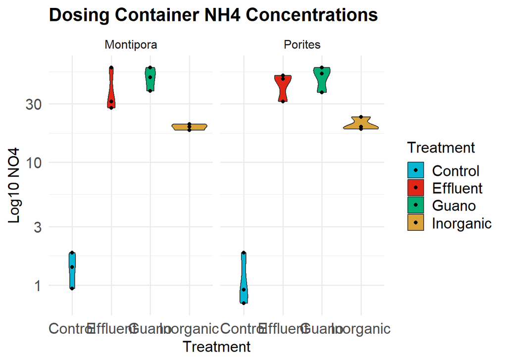

```r
# Violin Plot - NH4 pooled at all timepoints
ggplot(data=subset(nuts, Tank %in% c("Dosing")), aes(x=Treatment, y=Ammonia, fill=Treatment))+
  geom_violin()+
  facet_wrap(~Species) +
  geom_jitter(width=0)+
  ggtitle("Dosing Container NH4 Concentrations")+
  scale_fill_manual(values=naste_colors)+
  scale_y_continuous(trans = "log10", name = "Log10 NO4")
```

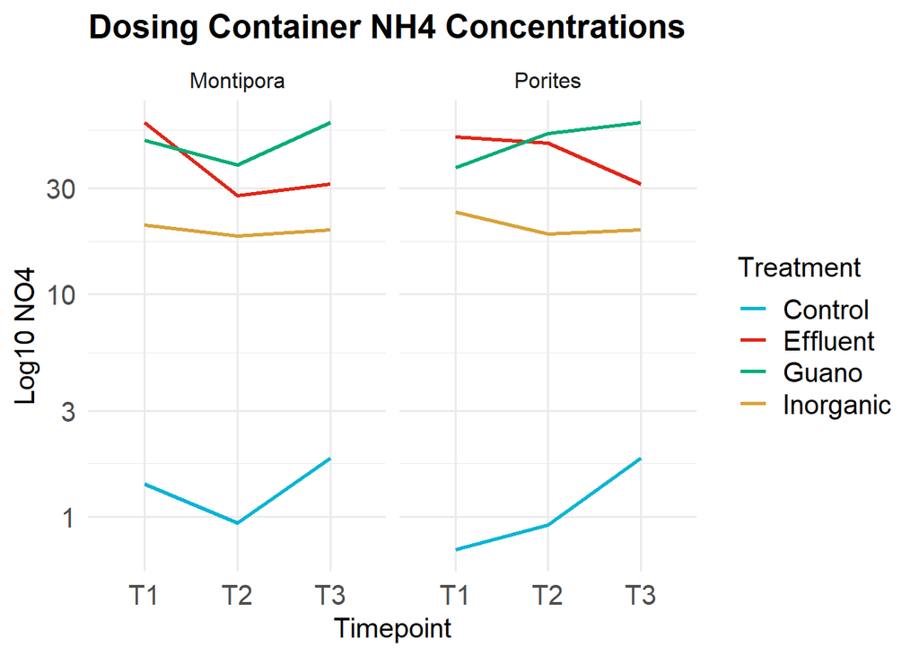

```r
# Line Plot - to show time series of NH4
ggplot(data=subset(nuts, Tank %in% c("Dosing")), aes(x=Timepoint, y=Ammonia, group=Treatment, color=Treatment))+
  geom_line(size = 1)+
  facet_wrap(~Species)+
  ggtitle("Dosing Container NH4 Concentrations")+
  scale_color_manual(values= naste_colors)+
  scale_y_continuous(trans = "log10", name = "Log10 NO4")
```